# Risk Factor Analysis

## Outcome Variable

**Outcome Variable:** ever_co

## Predictor Variables

**Intervention Variable:** nchldlt5

**Adjustment Set:**

- arm
- W_mage
- meducyrs
- feducyrs
- hhwealth_quart
- hfoodsec
- W_mhtcm
- W_mwtkg
- W_mbmi
- W_nrooms
- W_parity
- impfloor
- impsan
- safeh20
- delta_W_mage
- delta_meducyrs
- delta_feducyrs
- delta_hhwealth_quart
- delta_hfoodsec
- delta_W_mhtcm
- delta_W_mwtkg
- delta_W_mbmi
- delta_W_nrooms
- delta_W_parity
- delta_impfloor
- delta_impsan
- delta_safeh20

## Stratifying Variables

The analysis was stratified on these variable(s):

- agecat
- studyid
- country

## Data Summary

| agecat | studyid | country | nchldlt5 | ever_co | n_cell | n |
| --- | --- | --- | --- | --- | --- | --- |
| 0-24 months | ki1000108-IRC | INDIA | 1 | 0 | 69 | 410 |
| 0-24 months | ki1000108-IRC | INDIA | 1 | 1 | 20 | 410 |
| 0-24 months | ki1000108-IRC | INDIA | 2+ | 0 | 265 | 410 |
| 0-24 months | ki1000108-IRC | INDIA | 2+ | 1 | 56 | 410 |
| 0-24 months | ki1017093b-PROVIDE | BANGLADESH | 1 | 0 | 447 | 700 |
| 0-24 months | ki1017093b-PROVIDE | BANGLADESH | 1 | 1 | 65 | 700 |
| 0-24 months | ki1017093b-PROVIDE | BANGLADESH | 2+ | 0 | 163 | 700 |
| 0-24 months | ki1017093b-PROVIDE | BANGLADESH | 2+ | 1 | 25 | 700 |
| 0-24 months | ki1017093c-NIH-Crypto | BANGLADESH | 1 | 0 | 496 | 758 |
| 0-24 months | ki1017093c-NIH-Crypto | BANGLADESH | 1 | 1 | 45 | 758 |
| 0-24 months | ki1017093c-NIH-Crypto | BANGLADESH | 2+ | 0 | 191 | 758 |
| 0-24 months | ki1017093c-NIH-Crypto | BANGLADESH | 2+ | 1 | 26 | 758 |
| 0-24 months | ki1066203-TanzaniaChild2 | TANZANIA, UNITED REPUBLIC OF | 1 | 0 | 1552 | 2385 |
| 0-24 months | ki1066203-TanzaniaChild2 | TANZANIA, UNITED REPUBLIC OF | 1 | 1 | 85 | 2385 |
| 0-24 months | ki1066203-TanzaniaChild2 | TANZANIA, UNITED REPUBLIC OF | 2+ | 0 | 714 | 2385 |
| 0-24 months | ki1066203-TanzaniaChild2 | TANZANIA, UNITED REPUBLIC OF | 2+ | 1 | 34 | 2385 |
| 0-24 months | ki1112895-iLiNS-Zinc | BURKINA FASO | 1 | 0 | 956 | 3188 |
| 0-24 months | ki1112895-iLiNS-Zinc | BURKINA FASO | 1 | 1 | 117 | 3188 |
| 0-24 months | ki1112895-iLiNS-Zinc | BURKINA FASO | 2+ | 0 | 1849 | 3188 |
| 0-24 months | ki1112895-iLiNS-Zinc | BURKINA FASO | 2+ | 1 | 266 | 3188 |
| 0-24 months | ki1148112-LCNI-5 | MALAWI | 1 | 0 | 376 | 812 |
| 0-24 months | ki1148112-LCNI-5 | MALAWI | 1 | 1 | 15 | 812 |
| 0-24 months | ki1148112-LCNI-5 | MALAWI | 2+ | 0 | 394 | 812 |
| 0-24 months | ki1148112-LCNI-5 | MALAWI | 2+ | 1 | 27 | 812 |
| 0-24 months | kiGH5241-JiVitA-3 | BANGLADESH | 1 | 0 | 15656 | 26896 |
| 0-24 months | kiGH5241-JiVitA-3 | BANGLADESH | 1 | 1 | 1540 | 26896 |
| 0-24 months | kiGH5241-JiVitA-3 | BANGLADESH | 2+ | 0 | 8851 | 26896 |
| 0-24 months | kiGH5241-JiVitA-3 | BANGLADESH | 2+ | 1 | 849 | 26896 |
| 0-6 months | ki1000108-IRC | INDIA | 1 | 0 | 79 | 409 |
| 0-6 months | ki1000108-IRC | INDIA | 1 | 1 | 10 | 409 |
| 0-6 months | ki1000108-IRC | INDIA | 2+ | 0 | 305 | 409 |
| 0-6 months | ki1000108-IRC | INDIA | 2+ | 1 | 15 | 409 |
| 0-6 months | ki1017093b-PROVIDE | BANGLADESH | 1 | 0 | 491 | 700 |
| 0-6 months | ki1017093b-PROVIDE | BANGLADESH | 1 | 1 | 21 | 700 |
| 0-6 months | ki1017093b-PROVIDE | BANGLADESH | 2+ | 0 | 179 | 700 |
| 0-6 months | ki1017093b-PROVIDE | BANGLADESH | 2+ | 1 | 9 | 700 |
| 0-6 months | ki1017093c-NIH-Crypto | BANGLADESH | 1 | 0 | 531 | 758 |
| 0-6 months | ki1017093c-NIH-Crypto | BANGLADESH | 1 | 1 | 10 | 758 |
| 0-6 months | ki1017093c-NIH-Crypto | BANGLADESH | 2+ | 0 | 210 | 758 |
| 0-6 months | ki1017093c-NIH-Crypto | BANGLADESH | 2+ | 1 | 7 | 758 |
| 0-6 months | ki1066203-TanzaniaChild2 | TANZANIA, UNITED REPUBLIC OF | 1 | 0 | 1622 | 2385 |
| 0-6 months | ki1066203-TanzaniaChild2 | TANZANIA, UNITED REPUBLIC OF | 1 | 1 | 15 | 2385 |
| 0-6 months | ki1066203-TanzaniaChild2 | TANZANIA, UNITED REPUBLIC OF | 2+ | 0 | 744 | 2385 |
| 0-6 months | ki1066203-TanzaniaChild2 | TANZANIA, UNITED REPUBLIC OF | 2+ | 1 | 4 | 2385 |
| 0-6 months | ki1148112-LCNI-5 | MALAWI | 1 | 0 | 122 | 267 |
| 0-6 months | ki1148112-LCNI-5 | MALAWI | 1 | 1 | 0 | 267 |
| 0-6 months | ki1148112-LCNI-5 | MALAWI | 2+ | 0 | 145 | 267 |
| 0-6 months | ki1148112-LCNI-5 | MALAWI | 2+ | 1 | 0 | 267 |
| 0-6 months | kiGH5241-JiVitA-3 | BANGLADESH | 1 | 0 | 16380 | 26789 |
| 0-6 months | kiGH5241-JiVitA-3 | BANGLADESH | 1 | 1 | 730 | 26789 |
| 0-6 months | kiGH5241-JiVitA-3 | BANGLADESH | 2+ | 0 | 9347 | 26789 |
| 0-6 months | kiGH5241-JiVitA-3 | BANGLADESH | 2+ | 1 | 332 | 26789 |
| 6-24 months | ki1000108-IRC | INDIA | 1 | 0 | 73 | 410 |
| 6-24 months | ki1000108-IRC | INDIA | 1 | 1 | 16 | 410 |
| 6-24 months | ki1000108-IRC | INDIA | 2+ | 0 | 273 | 410 |
| 6-24 months | ki1000108-IRC | INDIA | 2+ | 1 | 48 | 410 |
| 6-24 months | ki1017093b-PROVIDE | BANGLADESH | 1 | 0 | 396 | 614 |
| 6-24 months | ki1017093b-PROVIDE | BANGLADESH | 1 | 1 | 52 | 614 |
| 6-24 months | ki1017093b-PROVIDE | BANGLADESH | 2+ | 0 | 143 | 614 |
| 6-24 months | ki1017093b-PROVIDE | BANGLADESH | 2+ | 1 | 23 | 614 |
| 6-24 months | ki1017093c-NIH-Crypto | BANGLADESH | 1 | 0 | 481 | 730 |
| 6-24 months | ki1017093c-NIH-Crypto | BANGLADESH | 1 | 1 | 39 | 730 |
| 6-24 months | ki1017093c-NIH-Crypto | BANGLADESH | 2+ | 0 | 186 | 730 |
| 6-24 months | ki1017093c-NIH-Crypto | BANGLADESH | 2+ | 1 | 24 | 730 |
| 6-24 months | ki1066203-TanzaniaChild2 | TANZANIA, UNITED REPUBLIC OF | 1 | 0 | 1303 | 2009 |
| 6-24 months | ki1066203-TanzaniaChild2 | TANZANIA, UNITED REPUBLIC OF | 1 | 1 | 80 | 2009 |
| 6-24 months | ki1066203-TanzaniaChild2 | TANZANIA, UNITED REPUBLIC OF | 2+ | 0 | 593 | 2009 |
| 6-24 months | ki1066203-TanzaniaChild2 | TANZANIA, UNITED REPUBLIC OF | 2+ | 1 | 33 | 2009 |
| 6-24 months | ki1112895-iLiNS-Zinc | BURKINA FASO | 1 | 0 | 956 | 3188 |
| 6-24 months | ki1112895-iLiNS-Zinc | BURKINA FASO | 1 | 1 | 117 | 3188 |
| 6-24 months | ki1112895-iLiNS-Zinc | BURKINA FASO | 2+ | 0 | 1849 | 3188 |
| 6-24 months | ki1112895-iLiNS-Zinc | BURKINA FASO | 2+ | 1 | 266 | 3188 |
| 6-24 months | ki1148112-LCNI-5 | MALAWI | 1 | 0 | 369 | 800 |
| 6-24 months | ki1148112-LCNI-5 | MALAWI | 1 | 1 | 15 | 800 |
| 6-24 months | ki1148112-LCNI-5 | MALAWI | 2+ | 0 | 389 | 800 |
| 6-24 months | ki1148112-LCNI-5 | MALAWI | 2+ | 1 | 27 | 800 |
| 6-24 months | kiGH5241-JiVitA-3 | BANGLADESH | 1 | 0 | 10266 | 17268 |
| 6-24 months | kiGH5241-JiVitA-3 | BANGLADESH | 1 | 1 | 924 | 17268 |
| 6-24 months | kiGH5241-JiVitA-3 | BANGLADESH | 2+ | 0 | 5503 | 17268 |
| 6-24 months | kiGH5241-JiVitA-3 | BANGLADESH | 2+ | 1 | 575 | 17268 |

The following strata were considered:

- agecat: 0-24 months, studyid: ki1000108-IRC, country: INDIA
- agecat: 0-24 months, studyid: ki1017093b-PROVIDE, country: BANGLADESH
- agecat: 0-24 months, studyid: ki1017093c-NIH-Crypto, country: BANGLADESH
- agecat: 0-24 months, studyid: ki1066203-TanzaniaChild2, country: TANZANIA, UNITED REPUBLIC OF
- agecat: 0-24 months, studyid: ki1112895-iLiNS-Zinc, country: BURKINA FASO
- agecat: 0-24 months, studyid: ki1148112-LCNI-5, country: MALAWI
- agecat: 0-24 months, studyid: kiGH5241-JiVitA-3, country: BANGLADESH
- agecat: 0-6 months, studyid: ki1000108-IRC, country: INDIA
- agecat: 0-6 months, studyid: ki1017093b-PROVIDE, country: BANGLADESH
- agecat: 0-6 months, studyid: ki1017093c-NIH-Crypto, country: BANGLADESH
- agecat: 0-6 months, studyid: ki1066203-TanzaniaChild2, country: TANZANIA, UNITED REPUBLIC OF
- agecat: 0-6 months, studyid: ki1148112-LCNI-5, country: MALAWI
- agecat: 0-6 months, studyid: kiGH5241-JiVitA-3, country: BANGLADESH
- agecat: 6-24 months, studyid: ki1000108-IRC, country: INDIA
- agecat: 6-24 months, studyid: ki1017093b-PROVIDE, country: BANGLADESH
- agecat: 6-24 months, studyid: ki1017093c-NIH-Crypto, country: BANGLADESH
- agecat: 6-24 months, studyid: ki1066203-TanzaniaChild2, country: TANZANIA, UNITED REPUBLIC OF
- agecat: 6-24 months, studyid: ki1112895-iLiNS-Zinc, country: BURKINA FASO
- agecat: 6-24 months, studyid: ki1148112-LCNI-5, country: MALAWI
- agecat: 6-24 months, studyid: kiGH5241-JiVitA-3, country: BANGLADESH

### Dropped Strata

Some strata were dropped due to rare outcomes:

- agecat: 0-6 months, studyid: ki1066203-TanzaniaChild2, country: TANZANIA, UNITED REPUBLIC OF
- agecat: 0-6 months, studyid: ki1148112-LCNI-5, country: MALAWI

## Methods Detail

We’re interested in the causal parameters $E[Y_a]$ for all values of $a \in \mathcal{A}$. These parameters represent the mean outcome if, possibly contrary to fact, we intervened to set all units to have $A=a$. Under the randomization and positivity assumptions, these are identified by the statistical parameters $\psi_a=E_W[E_{Y|A,W}(Y|A=a,W)]$. In addition, we’re interested in the mean of $Y$, $E[Y]$ under no intervention (the observed mean). We will estimate these parameters by using SuperLearner to fit the relevant likelihood factors – $E_{Y|A,W}(Y|A=a,W)$ and $p(A=a|W)$, and then updating our likelihood fit using a joint TMLE.

For unadjusted analyses ($W=\{\}$), initial likelihoods were estimated using Lrnr_glm to estimate the simple $E(Y|A)$ and Lrnr_mean to estimate $p(A)$. For adjusted analyses, a small library containing Lrnr_glmnet, Lrnr_xgboost, and Lrnr_mean was used.

Having estimated these parameters, we will then use the delta method to estimate relative risks and attributable risks relative to a prespecified baseline level of $A$.

# Results Detail

## Results Plots

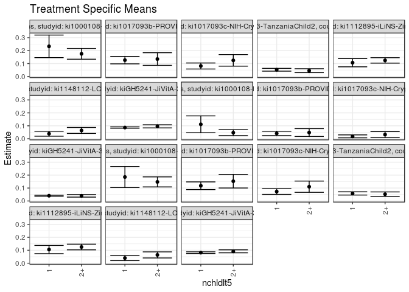

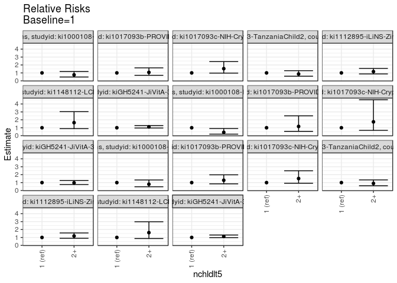

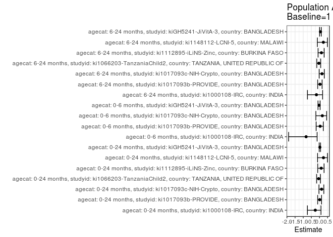

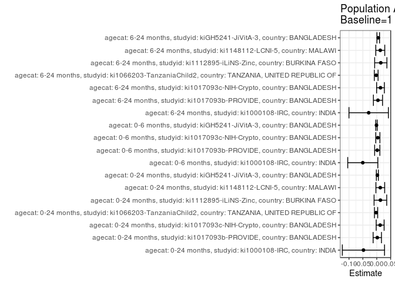

## Results Table

### Parameter: TSM

| agecat | studyid | country | intervention_level | baseline_level | estimate | ci_lower | ci_upper |
| --- | --- | --- | --- | --- | --- | --- | --- |
| 0-24 months | ki1000108-IRC | INDIA | 1 | NA | 0.2332144 | 0.1459585 | 0.3204703 |
| 0-24 months | ki1000108-IRC | INDIA | 2+ | NA | 0.1753014 | 0.1337297 | 0.2168730 |
| 0-24 months | ki1017093b-PROVIDE | BANGLADESH | 1 | NA | 0.1265911 | 0.0977809 | 0.1554013 |
| 0-24 months | ki1017093b-PROVIDE | BANGLADESH | 2+ | NA | 0.1351313 | 0.0862200 | 0.1840425 |
| 0-24 months | ki1017093c-NIH-Crypto | BANGLADESH | 1 | NA | 0.0813756 | 0.0581022 | 0.1046489 |
| 0-24 months | ki1017093c-NIH-Crypto | BANGLADESH | 2+ | NA | 0.1249135 | 0.0800711 | 0.1697558 |
| 0-24 months | ki1066203-TanzaniaChild2 | TANZANIA, UNITED REPUBLIC OF | 1 | NA | 0.0523509 | 0.0415319 | 0.0631698 |
| 0-24 months | ki1066203-TanzaniaChild2 | TANZANIA, UNITED REPUBLIC OF | 2+ | NA | 0.0451771 | 0.0300821 | 0.0602721 |
| 0-24 months | ki1112895-iLiNS-Zinc | BURKINA FASO | 1 | NA | 0.1069572 | 0.0750906 | 0.1388239 |
| 0-24 months | ki1112895-iLiNS-Zinc | BURKINA FASO | 2+ | NA | 0.1245589 | 0.1036471 | 0.1454707 |
| 0-24 months | ki1148112-LCNI-5 | MALAWI | 1 | NA | 0.0389657 | 0.0197081 | 0.0582232 |
| 0-24 months | ki1148112-LCNI-5 | MALAWI | 2+ | NA | 0.0640112 | 0.0408345 | 0.0871879 |
| 0-24 months | kiGH5241-JiVitA-3 | BANGLADESH | 1 | NA | 0.0865807 | 0.0814472 | 0.0917141 |
| 0-24 months | kiGH5241-JiVitA-3 | BANGLADESH | 2+ | NA | 0.0960225 | 0.0839697 | 0.1080752 |
| 0-6 months | ki1000108-IRC | INDIA | 1 | NA | 0.1114346 | 0.0462113 | 0.1766579 |
| 0-6 months | ki1000108-IRC | INDIA | 2+ | NA | 0.0469852 | 0.0238307 | 0.0701397 |
| 0-6 months | ki1017093b-PROVIDE | BANGLADESH | 1 | NA | 0.0410156 | 0.0238245 | 0.0582067 |
| 0-6 months | ki1017093b-PROVIDE | BANGLADESH | 2+ | NA | 0.0478723 | 0.0173323 | 0.0784124 |
| 0-6 months | ki1017093c-NIH-Crypto | BANGLADESH | 1 | NA | 0.0184843 | 0.0071267 | 0.0298419 |
| 0-6 months | ki1017093c-NIH-Crypto | BANGLADESH | 2+ | NA | 0.0322581 | 0.0087345 | 0.0557817 |
| 0-6 months | kiGH5241-JiVitA-3 | BANGLADESH | 1 | NA | 0.0405917 | 0.0370049 | 0.0441785 |
| 0-6 months | kiGH5241-JiVitA-3 | BANGLADESH | 2+ | NA | 0.0394952 | 0.0298632 | 0.0491271 |
| 6-24 months | ki1000108-IRC | INDIA | 1 | NA | 0.1851563 | 0.1038902 | 0.2664223 |
| 6-24 months | ki1000108-IRC | INDIA | 2+ | NA | 0.1474513 | 0.1086095 | 0.1862932 |
| 6-24 months | ki1017093b-PROVIDE | BANGLADESH | 1 | NA | 0.1177847 | 0.0881101 | 0.1474593 |
| 6-24 months | ki1017093b-PROVIDE | BANGLADESH | 2+ | NA | 0.1526096 | 0.1002662 | 0.2049529 |
| 6-24 months | ki1017093c-NIH-Crypto | BANGLADESH | 1 | NA | 0.0727758 | 0.0506548 | 0.0948968 |
| 6-24 months | ki1017093c-NIH-Crypto | BANGLADESH | 2+ | NA | 0.1102742 | 0.0666912 | 0.1538573 |
| 6-24 months | ki1066203-TanzaniaChild2 | TANZANIA, UNITED REPUBLIC OF | 1 | NA | 0.0581904 | 0.0457480 | 0.0706328 |
| 6-24 months | ki1066203-TanzaniaChild2 | TANZANIA, UNITED REPUBLIC OF | 2+ | NA | 0.0522668 | 0.0346629 | 0.0698707 |
| 6-24 months | ki1112895-iLiNS-Zinc | BURKINA FASO | 1 | NA | 0.1055780 | 0.0738123 | 0.1373437 |
| 6-24 months | ki1112895-iLiNS-Zinc | BURKINA FASO | 2+ | NA | 0.1252386 | 0.1033086 | 0.1471686 |
| 6-24 months | ki1148112-LCNI-5 | MALAWI | 1 | NA | 0.0398393 | 0.0200702 | 0.0596085 |
| 6-24 months | ki1148112-LCNI-5 | MALAWI | 2+ | NA | 0.0640789 | 0.0406255 | 0.0875323 |
| 6-24 months | kiGH5241-JiVitA-3 | BANGLADESH | 1 | NA | 0.0813387 | 0.0748843 | 0.0877931 |
| 6-24 months | kiGH5241-JiVitA-3 | BANGLADESH | 2+ | NA | 0.0918356 | 0.0803190 | 0.1033522 |

### Parameter: E(Y)

| agecat | studyid | country | intervention_level | baseline_level | estimate | ci_lower | ci_upper |
| --- | --- | --- | --- | --- | --- | --- | --- |
| 0-24 months | ki1000108-IRC | INDIA | NA | NA | 0.1853659 | 0.1477057 | 0.2230261 |
| 0-24 months | ki1017093b-PROVIDE | BANGLADESH | NA | NA | 0.1285714 | 0.1037574 | 0.1533855 |
| 0-24 months | ki1017093c-NIH-Crypto | BANGLADESH | NA | NA | 0.0936675 | 0.0729118 | 0.1144233 |
| 0-24 months | ki1066203-TanzaniaChild2 | TANZANIA, UNITED REPUBLIC OF | NA | NA | 0.0498952 | 0.0411552 | 0.0586352 |
| 0-24 months | ki1112895-iLiNS-Zinc | BURKINA FASO | NA | NA | 0.1201380 | 0.1003403 | 0.1399357 |
| 0-24 months | ki1148112-LCNI-5 | MALAWI | NA | NA | 0.0517241 | 0.0364818 | 0.0669665 |
| 0-24 months | kiGH5241-JiVitA-3 | BANGLADESH | NA | NA | 0.0888236 | 0.0849161 | 0.0927312 |
| 0-6 months | ki1000108-IRC | INDIA | NA | NA | 0.0611247 | 0.0378797 | 0.0843697 |
| 0-6 months | ki1017093b-PROVIDE | BANGLADESH | NA | NA | 0.0428571 | 0.0278427 | 0.0578716 |
| 0-6 months | ki1017093c-NIH-Crypto | BANGLADESH | NA | NA | 0.0224274 | 0.0118796 | 0.0329753 |
| 0-6 months | kiGH5241-JiVitA-3 | BANGLADESH | NA | NA | 0.0396431 | 0.0371403 | 0.0421459 |
| 6-24 months | ki1000108-IRC | INDIA | NA | NA | 0.1560976 | 0.1209228 | 0.1912723 |
| 6-24 months | ki1017093b-PROVIDE | BANGLADESH | NA | NA | 0.1221498 | 0.0962275 | 0.1480722 |
| 6-24 months | ki1017093c-NIH-Crypto | BANGLADESH | NA | NA | 0.0863014 | 0.0659171 | 0.1066856 |
| 6-24 months | ki1066203-TanzaniaChild2 | TANZANIA, UNITED REPUBLIC OF | NA | NA | 0.0562469 | 0.0461696 | 0.0663242 |
| 6-24 months | ki1112895-iLiNS-Zinc | BURKINA FASO | NA | NA | 0.1201380 | 0.1003403 | 0.1399357 |
| 6-24 months | ki1148112-LCNI-5 | MALAWI | NA | NA | 0.0525000 | 0.0370352 | 0.0679648 |
| 6-24 months | kiGH5241-JiVitA-3 | BANGLADESH | NA | NA | 0.0868080 | 0.0821488 | 0.0914672 |

### Parameter: RR

| agecat | studyid | country | intervention_level | baseline_level | estimate | ci_lower | ci_upper |
| --- | --- | --- | --- | --- | --- | --- | --- |
| 0-24 months | ki1000108-IRC | INDIA | 1 | 1 | 1.0000000 | 1.0000000 | 1.0000000 |
| 0-24 months | ki1000108-IRC | INDIA | 2+ | 1 | 0.7516746 | 0.4823203 | 1.1714512 |
| 0-24 months | ki1017093b-PROVIDE | BANGLADESH | 1 | 1 | 1.0000000 | 1.0000000 | 1.0000000 |
| 0-24 months | ki1017093b-PROVIDE | BANGLADESH | 2+ | 1 | 1.0674628 | 0.6967335 | 1.6354557 |
| 0-24 months | ki1017093c-NIH-Crypto | BANGLADESH | 1 | 1 | 1.0000000 | 1.0000000 | 1.0000000 |
| 0-24 months | ki1017093c-NIH-Crypto | BANGLADESH | 2+ | 1 | 1.5350238 | 0.9700563 | 2.4290325 |
| 0-24 months | ki1066203-TanzaniaChild2 | TANZANIA, UNITED REPUBLIC OF | 1 | 1 | 1.0000000 | 1.0000000 | 1.0000000 |
| 0-24 months | ki1066203-TanzaniaChild2 | TANZANIA, UNITED REPUBLIC OF | 2+ | 1 | 0.8629685 | 0.5826144 | 1.2782289 |
| 0-24 months | ki1112895-iLiNS-Zinc | BURKINA FASO | 1 | 1 | 1.0000000 | 1.0000000 | 1.0000000 |
| 0-24 months | ki1112895-iLiNS-Zinc | BURKINA FASO | 2+ | 1 | 1.1645676 | 0.8692020 | 1.5603021 |
| 0-24 months | ki1148112-LCNI-5 | MALAWI | 1 | 1 | 1.0000000 | 1.0000000 | 1.0000000 |
| 0-24 months | ki1148112-LCNI-5 | MALAWI | 2+ | 1 | 1.6427600 | 0.8899230 | 3.0324652 |
| 0-24 months | kiGH5241-JiVitA-3 | BANGLADESH | 1 | 1 | 1.0000000 | 1.0000000 | 1.0000000 |
| 0-24 months | kiGH5241-JiVitA-3 | BANGLADESH | 2+ | 1 | 1.1090521 | 0.9693317 | 1.2689120 |
| 0-6 months | ki1000108-IRC | INDIA | 1 | 1 | 1.0000000 | 1.0000000 | 1.0000000 |
| 0-6 months | ki1000108-IRC | INDIA | 2+ | 1 | 0.4216391 | 0.1965842 | 0.9043429 |
| 0-6 months | ki1017093b-PROVIDE | BANGLADESH | 1 | 1 | 1.0000000 | 1.0000000 | 1.0000000 |
| 0-6 months | ki1017093b-PROVIDE | BANGLADESH | 2+ | 1 | 1.1671733 | 0.5440406 | 2.5040289 |
| 0-6 months | ki1017093c-NIH-Crypto | BANGLADESH | 1 | 1 | 1.0000000 | 1.0000000 | 1.0000000 |
| 0-6 months | ki1017093c-NIH-Crypto | BANGLADESH | 2+ | 1 | 1.7451613 | 0.6725110 | 4.5286812 |
| 0-6 months | kiGH5241-JiVitA-3 | BANGLADESH | 1 | 1 | 1.0000000 | 1.0000000 | 1.0000000 |
| 0-6 months | kiGH5241-JiVitA-3 | BANGLADESH | 2+ | 1 | 0.9729861 | 0.7519874 | 1.2589334 |
| 6-24 months | ki1000108-IRC | INDIA | 1 | 1 | 1.0000000 | 1.0000000 | 1.0000000 |
| 6-24 months | ki1000108-IRC | INDIA | 2+ | 1 | 0.7963615 | 0.4771196 | 1.3292090 |
| 6-24 months | ki1017093b-PROVIDE | BANGLADESH | 1 | 1 | 1.0000000 | 1.0000000 | 1.0000000 |
| 6-24 months | ki1017093b-PROVIDE | BANGLADESH | 2+ | 1 | 1.2956657 | 0.8456235 | 1.9852212 |
| 6-24 months | ki1017093c-NIH-Crypto | BANGLADESH | 1 | 1 | 1.0000000 | 1.0000000 | 1.0000000 |
| 6-24 months | ki1017093c-NIH-Crypto | BANGLADESH | 2+ | 1 | 1.5152597 | 0.9203403 | 2.4947424 |
| 6-24 months | ki1066203-TanzaniaChild2 | TANZANIA, UNITED REPUBLIC OF | 1 | 1 | 1.0000000 | 1.0000000 | 1.0000000 |
| 6-24 months | ki1066203-TanzaniaChild2 | TANZANIA, UNITED REPUBLIC OF | 2+ | 1 | 0.8982031 | 0.6027311 | 1.3385219 |
| 6-24 months | ki1112895-iLiNS-Zinc | BURKINA FASO | 1 | 1 | 1.0000000 | 1.0000000 | 1.0000000 |
| 6-24 months | ki1112895-iLiNS-Zinc | BURKINA FASO | 2+ | 1 | 1.1862190 | 0.8962813 | 1.5699486 |
| 6-24 months | ki1148112-LCNI-5 | MALAWI | 1 | 1 | 1.0000000 | 1.0000000 | 1.0000000 |
| 6-24 months | ki1148112-LCNI-5 | MALAWI | 2+ | 1 | 1.6084334 | 0.8680407 | 2.9803419 |
| 6-24 months | kiGH5241-JiVitA-3 | BANGLADESH | 1 | 1 | 1.0000000 | 1.0000000 | 1.0000000 |
| 6-24 months | kiGH5241-JiVitA-3 | BANGLADESH | 2+ | 1 | 1.1290511 | 0.9734151 | 1.3095713 |

### Parameter: PAR

| agecat | studyid | country | intervention_level | baseline_level | estimate | ci_lower | ci_upper |
| --- | --- | --- | --- | --- | --- | --- | --- |
| 0-24 months | ki1000108-IRC | INDIA | 1 | NA | -0.0478486 | -0.1238472 | 0.0281501 |
| 0-24 months | ki1017093b-PROVIDE | BANGLADESH | 1 | NA | 0.0019803 | -0.0130884 | 0.0170491 |
| 0-24 months | ki1017093c-NIH-Crypto | BANGLADESH | 1 | NA | 0.0122920 | -0.0020113 | 0.0265953 |
| 0-24 months | ki1066203-TanzaniaChild2 | TANZANIA, UNITED REPUBLIC OF | 1 | NA | -0.0024557 | -0.0082952 | 0.0033838 |
| 0-24 months | ki1112895-iLiNS-Zinc | BURKINA FASO | 1 | NA | 0.0131808 | -0.0095822 | 0.0359438 |
| 0-24 months | ki1148112-LCNI-5 | MALAWI | 1 | NA | 0.0127585 | -0.0030826 | 0.0285996 |
| 0-24 months | kiGH5241-JiVitA-3 | BANGLADESH | 1 | NA | 0.0022429 | -0.0014051 | 0.0058910 |
| 0-6 months | ki1000108-IRC | INDIA | 1 | NA | -0.0503099 | -0.1045566 | 0.0039368 |
| 0-6 months | ki1017093b-PROVIDE | BANGLADESH | 1 | NA | 0.0018415 | -0.0075736 | 0.0112566 |
| 0-6 months | ki1017093c-NIH-Crypto | BANGLADESH | 1 | NA | 0.0039432 | -0.0035482 | 0.0114345 |
| 0-6 months | kiGH5241-JiVitA-3 | BANGLADESH | 1 | NA | -0.0009486 | -0.0035710 | 0.0016739 |
| 6-24 months | ki1000108-IRC | INDIA | 1 | NA | -0.0290587 | -0.1001229 | 0.0420054 |
| 6-24 months | ki1017093b-PROVIDE | BANGLADESH | 1 | NA | 0.0043652 | -0.0120950 | 0.0208253 |
| 6-24 months | ki1017093c-NIH-Crypto | BANGLADESH | 1 | NA | 0.0135256 | -0.0004706 | 0.0275217 |
| 6-24 months | ki1066203-TanzaniaChild2 | TANZANIA, UNITED REPUBLIC OF | 1 | NA | -0.0019435 | -0.0087431 | 0.0048561 |
| 6-24 months | ki1112895-iLiNS-Zinc | BURKINA FASO | 1 | NA | 0.0145600 | -0.0074983 | 0.0366183 |
| 6-24 months | ki1148112-LCNI-5 | MALAWI | 1 | NA | 0.0126607 | -0.0035518 | 0.0288731 |
| 6-24 months | kiGH5241-JiVitA-3 | BANGLADESH | 1 | NA | 0.0054692 | 0.0007819 | 0.0101565 |

### Parameter: PAF

| agecat | studyid | country | intervention_level | baseline_level | estimate | ci_lower | ci_upper |
| --- | --- | --- | --- | --- | --- | --- | --- |
| 0-24 months | ki1000108-IRC | INDIA | 1 | NA | -0.2581304 | -0.7421368 | 0.0914078 |
| 0-24 months | ki1017093b-PROVIDE | BANGLADESH | 1 | NA | 0.0154026 | -0.1090449 | 0.1258856 |
| 0-24 months | ki1017093c-NIH-Crypto | BANGLADESH | 1 | NA | 0.1312298 | -0.0335325 | 0.2697262 |
| 0-24 months | ki1066203-TanzaniaChild2 | TANZANIA, UNITED REPUBLIC OF | 1 | NA | -0.0492167 | -0.1727643 | 0.0613155 |
| 0-24 months | ki1112895-iLiNS-Zinc | BURKINA FASO | 1 | NA | 0.1097137 | -0.1050920 | 0.2827658 |
| 0-24 months | ki1148112-LCNI-5 | MALAWI | 1 | NA | 0.2466641 | -0.1186593 | 0.4926829 |
| 0-24 months | kiGH5241-JiVitA-3 | BANGLADESH | 1 | NA | 0.0252515 | -0.0166222 | 0.0654005 |
| 0-6 months | ki1000108-IRC | INDIA | 1 | NA | -0.8230703 | -1.8996185 | -0.1462147 |
| 0-6 months | ki1017093b-PROVIDE | BANGLADESH | 1 | NA | 0.0429687 | -0.2033820 | 0.2388877 |
| 0-6 months | ki1017093c-NIH-Crypto | BANGLADESH | 1 | NA | 0.1758182 | -0.2211410 | 0.4437369 |
| 0-6 months | kiGH5241-JiVitA-3 | BANGLADESH | 1 | NA | -0.0239273 | -0.0923149 | 0.0401786 |
| 6-24 months | ki1000108-IRC | INDIA | 1 | NA | -0.1861574 | -0.7400487 | 0.1914195 |
| 6-24 months | ki1017093b-PROVIDE | BANGLADESH | 1 | NA | 0.0357362 | -0.1084957 | 0.1612013 |
| 6-24 months | ki1017093c-NIH-Crypto | BANGLADESH | 1 | NA | 0.1567248 | -0.0175772 | 0.3011704 |
| 6-24 months | ki1066203-TanzaniaChild2 | TANZANIA, UNITED REPUBLIC OF | 1 | NA | -0.0345530 | -0.1626085 | 0.0793977 |
| 6-24 months | ki1112895-iLiNS-Zinc | BURKINA FASO | 1 | NA | 0.1211942 | -0.0879772 | 0.2901508 |
| 6-24 months | ki1148112-LCNI-5 | MALAWI | 1 | NA | 0.2411557 | -0.1284806 | 0.4897168 |
| 6-24 months | kiGH5241-JiVitA-3 | BANGLADESH | 1 | NA | 0.0630037 | 0.0074747 | 0.1154261 |